# DATS6101 Group Project: Mobile Apps Analysis

Jonathan Giguere, Jesse Borg, Ese Emuraye, Sarah Gates

October 30th 2019

## Section 1: Introduction

The popularity of smartphones has increased greatly every year since Apple released the Iphone in 2007, with approximately 10 billion smartphones sold worldwide since then (Gartner, 2019). Of these 10 billion, iPhones account for almost 20% of sales with a total revenue of $165 billion in 2018 alone (Amarendra, 2019). Since the meteoric rise of the smartphone and tech industries, many app developers have taken the opportunity to develop their own apps for different operating systems and made them available to download on the App Store and/or the Google Play Store. Today, there are over 2 million iOS apps (PocketGamer.biz., 2019). and 2.5 million apps on the Google Play Store (AppBrain., 2019). On average, people spend around 3 hours a day on their phones [Hacker Noon](https://hackernoon.com). Due to the huge popularity of apps, there is a wide variety of genres available for every type of audience with a wide range of pricing. Since many people invest so much time and effort into apps, app data has become an interesting and relevant topic to conduct more research on.

The satisfaction users derived from interacting with installed apps is often the first metric which provides meaning insights to app developers as well as company management on how well an app is performing. In addition, app consumers can use such metrics, if available, to make comparison within and/or across app categories to make judgements. The objective of this analysis is to understand the different metrics, associations and relationships that exist in the app data, with an aim to unlock insights that will help app developers, management of technology companies as well as other app consumers to make sound judgements.

This report focuses on a sample of apps from the Google Play Store, where the composition of this sample will be analysed in depth. The report itself will contain 6 additional chapters: Chapter 2 looks at the source data and the general composition of the dataset. Chapter 3 compares the apps in the App Store to that in the Google Play Store; chapter 4 looks at the different app categories; chapter 5 analyzes the pricing of the apps; chapter 6 shows how app features are related to the user rating. Finally chapter 7 is the report conclusion where we report our key findings and takeaways based on the analysis.

## Section 2: Description of Data

### 2.1 Discussion of Data Sources

App Store and Google Play Store datasets were both obtained from [Kaggle](https://www.kaggle.com). First, we will describe the data pertaining to the Google Play Store.

#### Google Play Store Data

The Google Play Store dataset contains records for 10,840 different apps. The variables, and their descriptions are given below:

- **App** - The name of the application
- **Category** - The category that the app belongs in
- **Rating** - The current app rating on a scale from 1 to 5 (1 being the lowest)
- **Reviews** - The number of reviews for the app
- **Size** - Size of the app given in MB
- **Installs** - Number of installs given as categories (ex. 10,000+)
- **Type** - Tells which apps are free and which require payment
- **Price** - Gives the Price for each app
- **Content_Rating** - Indicates which age groups the app is approved for
- **Last Updated** - Date the app was last updated
- **Current.Ver** - Current Version of the app

#### Apple Store Data

The Apple App Store dataset contains records for 7,197 different apps. The variables, and their descriptions are given below:

- **App** - The name of the application
- **Category** - The category that the app belongs in
- **Rating** - The current app rating on a scale from 1 to 5 (1 being the lowest)
- **Reviews** - The number of reviews for the app
- **Size** - Size of the app given in MB
- **Price** - Gives the Price for each app
- **Content_Rating** - Indicates which age groups the app is approved for
- **Current_Ver** - Current_Version of the app

### 2.2 Cleaning the Data

As with most raw datasets, it is imperative to perform some cleaning operations to remove invalid data.

#### 2.2.1 Removing Null Values

Our first step in cleaning the data is to identify null values. This chart displays the count of null values in each category of the Google Play Store dataset. The only field with null values is Rating with 1474 missing values. We will store these values in a separate data frame in case we would like to do future analysis on this data. Then we will remove them from the main googlePlay dataset.

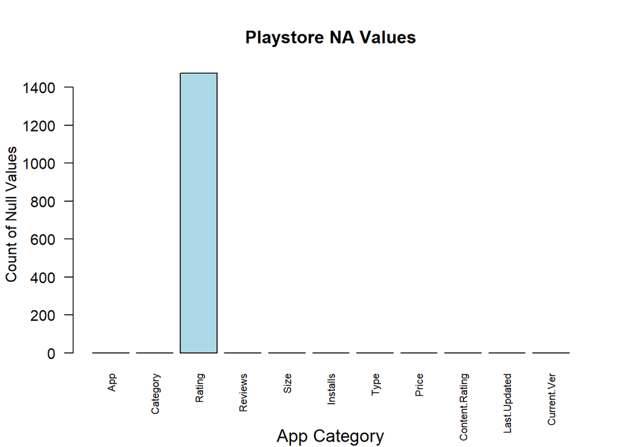

### 2.2.2 Remove Duplicate Values

Also, we will check whether there are duplicates. We will do this by checking the difference between all app names and all values. At first, when we looked at all unique rows in the Google Play Store dataset, some apps still had multiple lines. This is most likely because of conflicting values in other variables. To remove this noise, we will narrow the data down to only unique app names and remove duplicate apps. There are 1170 duplicates in the data. The next step is to remove duplicates from playstore.

### 2.2.3 Clean up Variables for Analysis

Next, to clean the data we will change the Installs variable from a nominal categorical variable to an ordinal categorical variable. Installs is a variable buckets the range of the number of times an app has been installed in log intervals of 1, 5, 10, 50, 100, 500, etc. We will place the factor levels in order from least to greatest. Then we will create two new variables that deal with further cleaning of Installs. InstallsNum strips the commas and “+” signs from the values so that the value can be converted to a number. Lastly regarding the Installs data, InstallsLog keeps Installs as a factor, but reassigns the values starting with 5 to its’ most previous 1 value so that they can be bucketed into a coherent log10 scale.

Since the price variable is a nominal factor in the original dataset, we must clean this up as well. We will now convert the price to a numeric by stripping the dollar sign and changing the variable type. Then for further analysis, we will create a new column called Price Categories and bucket the prices into Cheap, Expensive, and Very Expensive ($0 to $9.99, $10+ to $99.99, $100+ and greater respectively). This will be further expanded upon in section five.

## Section 3: Comparison of the App Store and Google Play Store

We will begin our analysis by comparing both the App Store and the Google Play Store datasets. After comparing both data sources, we will select one to use for further in depth analysis.

The App Store dataset originally contained 7197 different apps whereas the Google Play Store originally contained 10840. After the cleaning was performed, the Google Play Store has 8196 records for different apps.

### 3.1 SMART Question: Are there any variables present in one dataset that do not exist in the other?

Here we can see that the Google Play Store has more variables of interest than the App Store. The App Store does not have a variable for number of installs, which is something we might want to use in our analysis.

| Google Play Store | App Store |
| --- | --- |
| App | App |
| Category | Category |
| Rating | Rating |
| Reviews | Reviews |
| Size | Size |
| Installs | *N/A* |
| Type | *N/A* |
| Price | Price |
| Content.Rating | Content_Rating |
| Last.Updated | *N/A* |
| Current.Ver | Current_Ver |

### 3.2 SMART Question: How do users rate apps in each app store?

Rating will most likely be a response variable of interest later in our analysis so we begin our comparison of the two app stores by looking at the distributions of ratings for each.

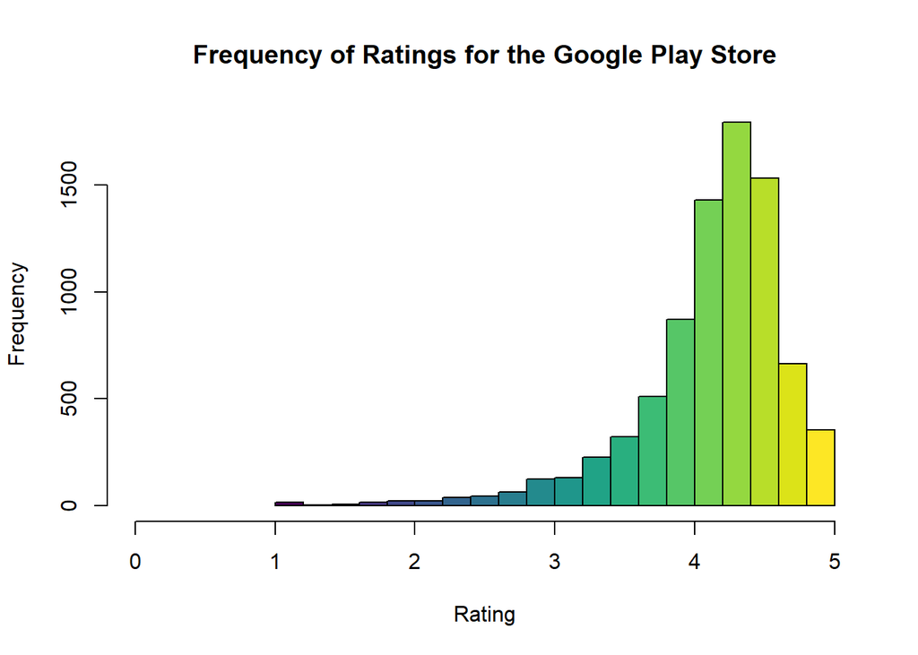

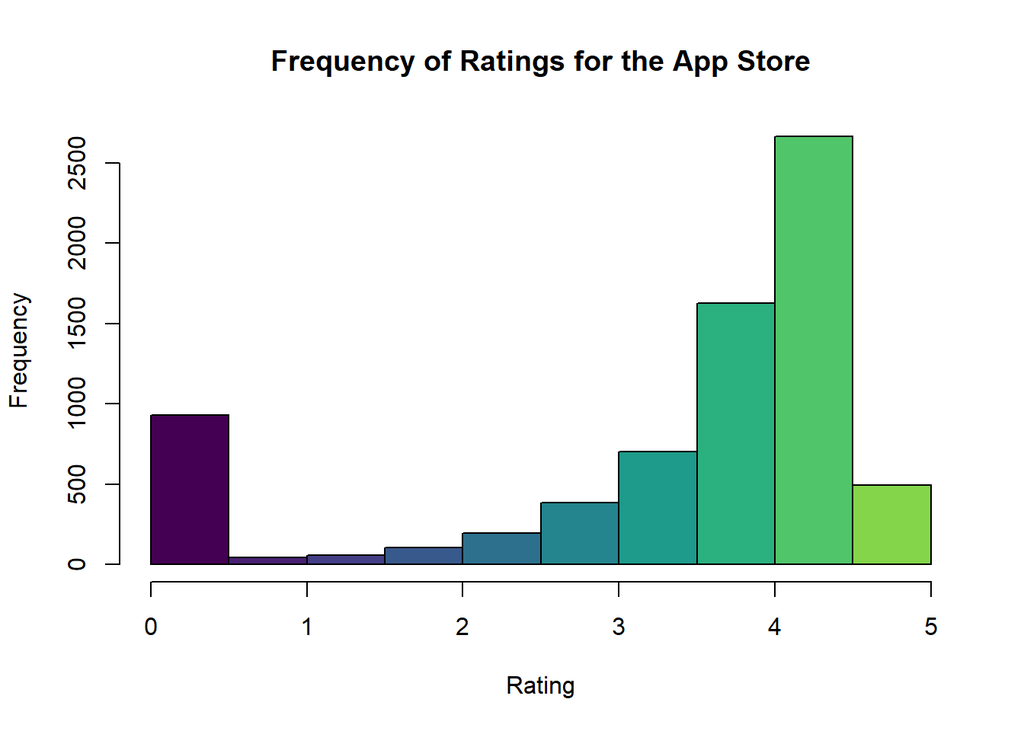

Upon inspection of the frequency distributions for each, we can see that neither is normally distributed and both are left skewed favoring higher rating. Due to the non-normal distributions, a two-sample t-test cannot be performed to evaluate the relationship between average ratings in each store. Instead we have simply calculated the mean and standard deviation of each for further comparison.

| Statistic | Google Play Store | App Store |
| --- | --- | --- |
| Mean | 4.17 | 3.53 |
| Standard Deviation | 0.54 | 1.52 |

We notice that the Google Play Store has a higher average rating for its apps than the App Store. We also notice that the variation in rating is lower in the Google Play Store. Some of this phenemenon could be attributed to the fact that the Google Play Store has ratings in increments of 0.1 while the App Store uses increments of 0.5.

### 3.3 SMART Question: How many apps are available in both app stores and how do their ratings compare?

After using the intersect() function to compare app names in both stores, there are a total of **328** apps in common. Now that we have dataframes containing common apps in both stores, we can revisit our ratings histogram to get a better idea of which store rates higher on average.

Upon inspection, the histograms (not pictured for brevity) were left skewed and not normally distributed so performing a two-sided t-test would be inappropriate here. As such, we have calculated the mean and standard deviation of each below and compared it to the mean and standard deviation from above where all apps were considered.

[output not shown]

Once again, the Google Play Store has higher average ratings and than the App Store and less variation. This tells us that for the exact same apps present in both stores, they tend to be rated higher in the Google Play Store.

### 3.4 SMART Question: Is one store more expensive than the other?

Before selecting one dataset to analyze further, we thought it would be wise to look at price comparisons between the two in case there are differences. In order to do so, we combined our dataframes consisting of all apps found in both stores. This allowed us to create a bar chart showing the sum of Price for each store for all shared apps.

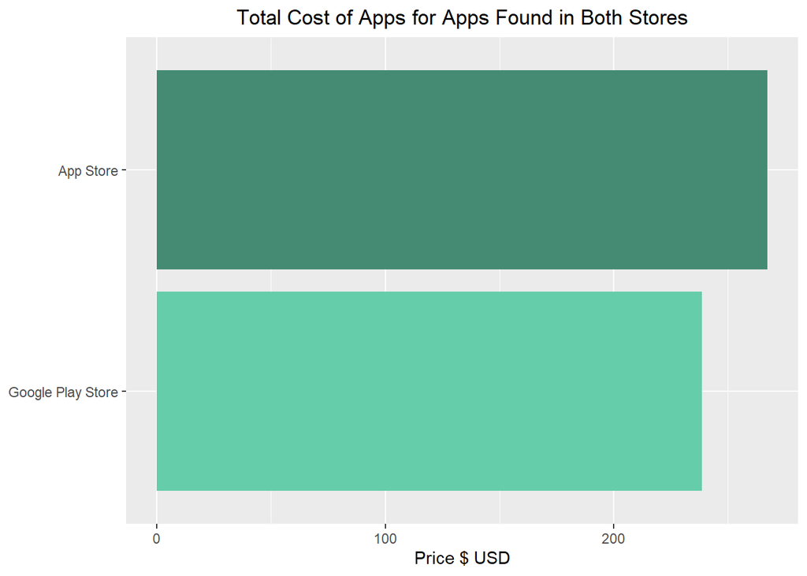

Upon inspection of the chart, we can see that some of the same apps differ in price depending which store they are in. Based on the apps the original datasets have in common, it would be more expensive to purchase all of them from the App Store. This could mean that the Apple App Store is more expensive, or at least it is for the apps present in our sample.

## Section 4: App Categories

Based on the analysis carried out in the previous, we have adopted the Google Play Store dataset for further analysis. Here, we carry out several analyses how the category of an app affects our features of the app data

### 4.1 SMART Question

Does app category have a correlation with rating, which categories in the Google Play Store have the highest priced apps and which category has the most highly rated apps?

### 4.2 Category Analysis

By grouping apps by category, we can determine the average rating by category and average price, as well as overall number of apps and number of apps by category. The most common categories are family, game and tools; below the category distrubution of apps is shown.

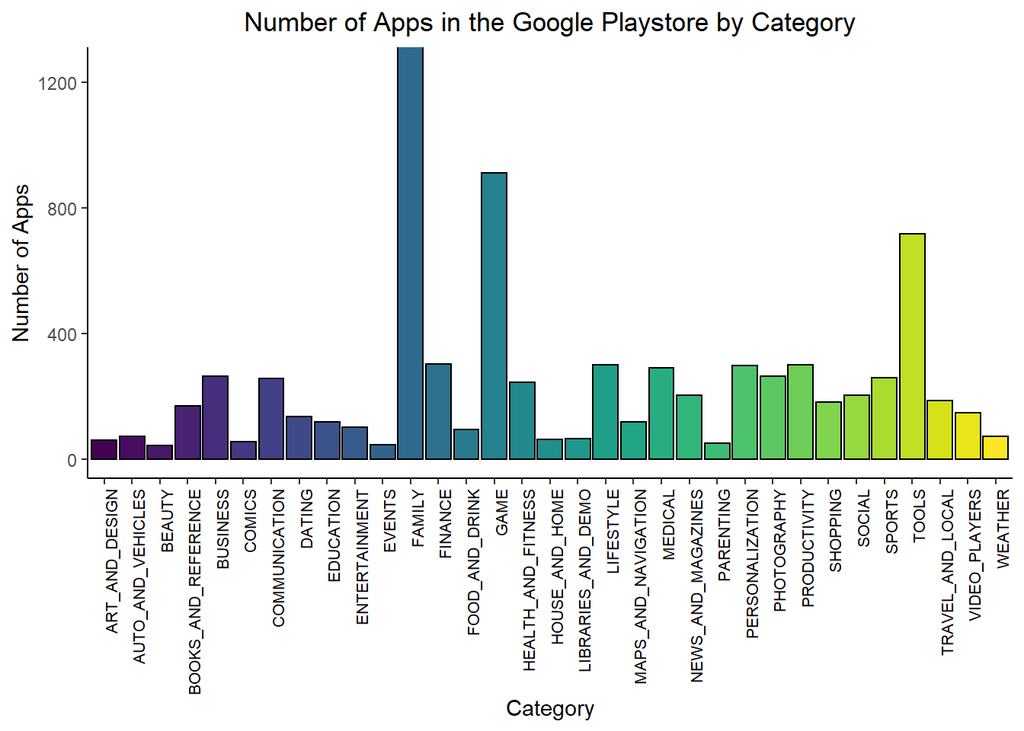

### 4.3 Categories by Rating

To find the highest and lowest rated categories, the ratings were aggregated according to the app category and the mean was then found for each category. Once the means were found, they were then plotted and a conclusion was drawn.

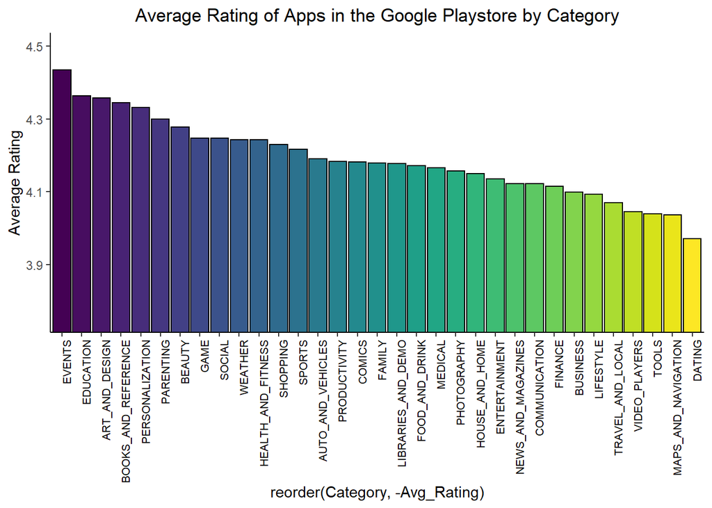

Highest and Lowest Average Ratings by Category

The highest rated categories on average are Events, Education and Art & Desgin, while the lowest rated categories are Maps & Navigation, Tools and Dating.

### 4.4 Categories by Price

To get the average price of each category, a new subset was created which just contained the paid apps. Then, similarly to the previous section, the prices were aggregated according to the category, the means were calculated and then plotted.

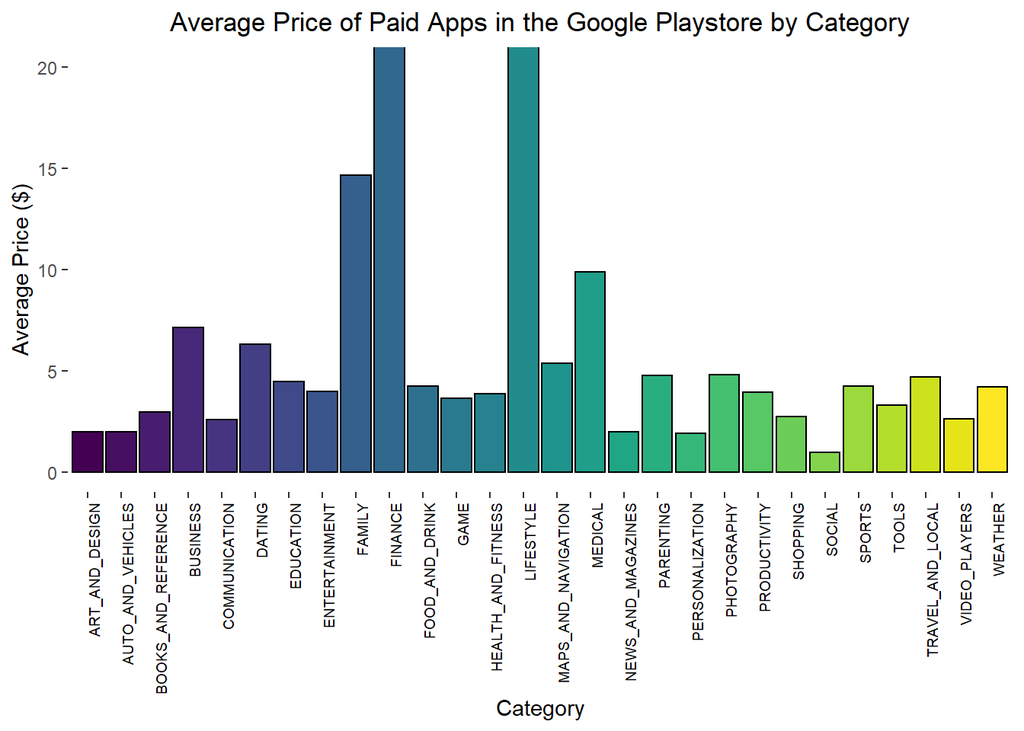

Highest Average Price by Category

Even though most of the apps in the Google Play Store are free; with 7592 free apps and 604 paid apps. Out of those paid apps, the most expensive ones on average are Finance and Lifestyle apps by a long shot.

### 4.5 Which app category in the Google Play Store receives most high ratings?

In this section, we would like to identify the most well rated app categories in the Google Play Store. We define ‘most well rated’ as ratings that are greater or equal to 4.8. The score 4.8 is chosen because 95% of app ratings in the Google Play Store are below 4.8. In other words, only 5% of the Google Play Store apps have ratings that are greater or equal to 4.8. Therefore, the 95th percentile helps us to filter the best rated apps.

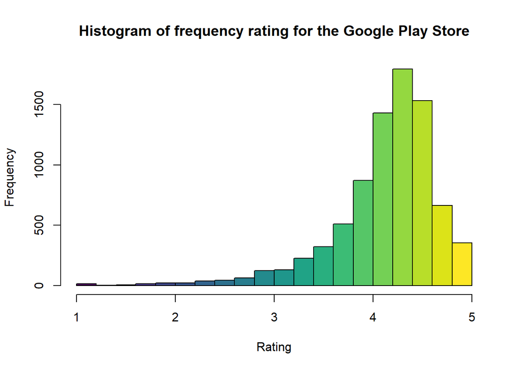

According to the 95th percentile, the apps in the top 5% having a rating of 4.8 or higher.

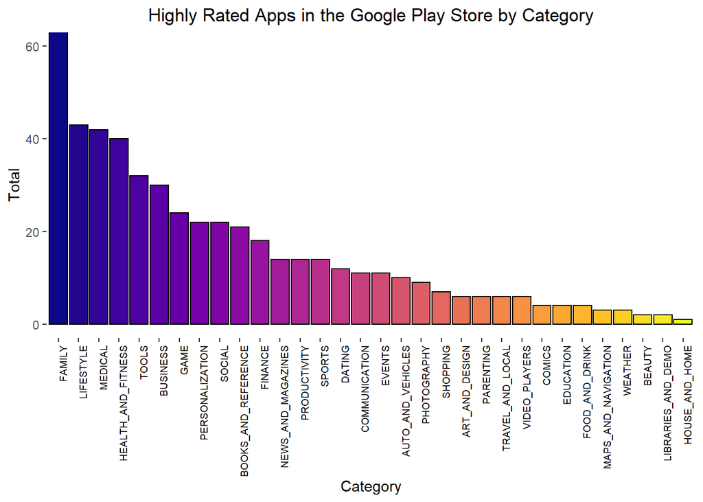

Categories with the most highly rated apps.

Catergories with the highest ratings are Family (by a large margin), then Lifestyle, Medical and Health & Fitness being very similar.

Overall; the highest rated apps on average are in the Events category, the most expensive apps are in the Finance category and the category with the most highly rated apps are Family.

## Section 5: App Pricing

In this section, we carry out several analyses how the price of an app affects other features of the app data. We seek to understand does the price influence the distribution of apps across category, rating and content rating as well as how the users rate paid apps in the Google Play Store

There are 7592 free apps and 604 paid apps corresponding to 92.6% and 7.37% respectively in Google playstore

### 5.1 SMART Question: Do users rate free apps better than paid apps across different categories?

For the different categories in Google Playstore, we want to understand the overall rating behavior of users for free apps as well as paid apps

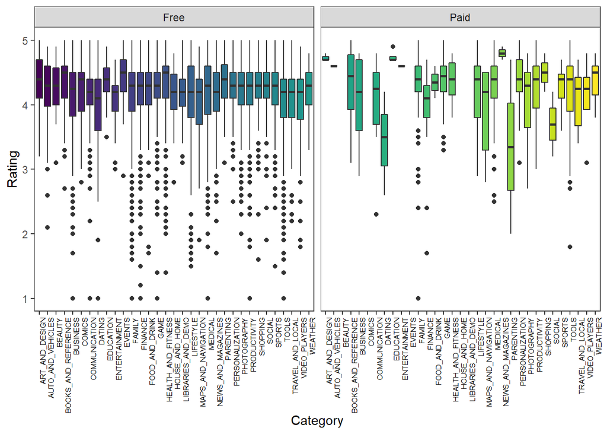

From the boxplot above, we observe that free apps have a well distributed mean rating across categories compared to paid apps. We plot separate bar charts to have a clearer illustration of how the average ratings are distributed across different categories

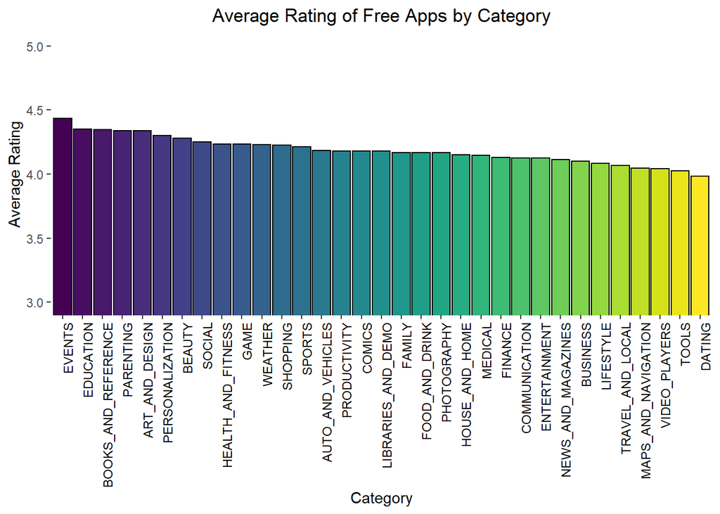

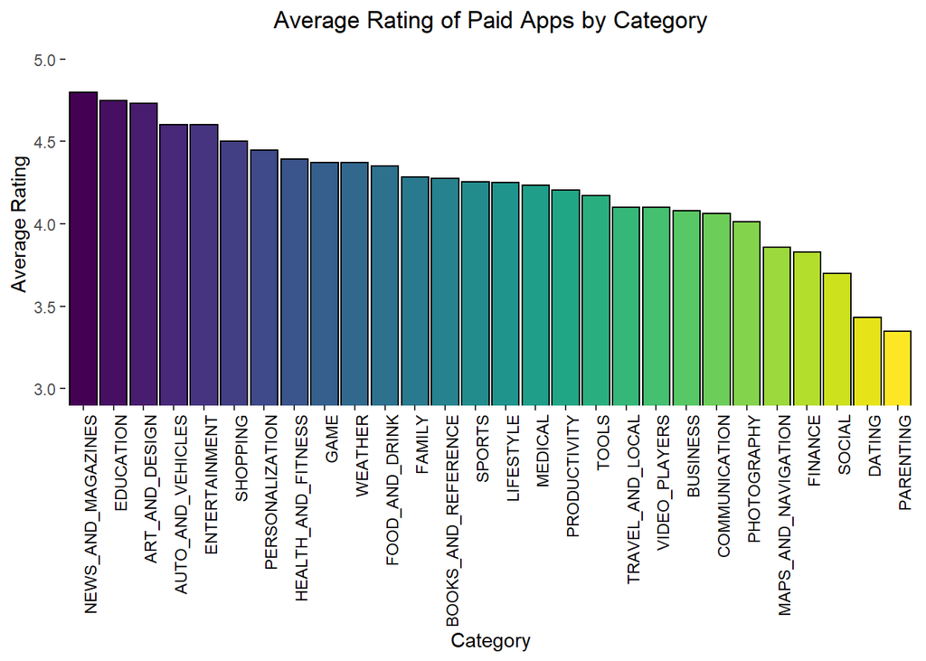

### 5.2 SMART Question: What are the top 5 rated apps in the free and paid price category

Catergories with the highest ratings among free apps are Events, Education, Books and Reference, Parenting and Art & Design. With paid apps, the highest rated categories are quite different having: News & Magazines, Education, Art & Design, Auto & Vehicles and Entertainment

### 5.3 SMART Question: How do users rate apps across different content rating for free and paid apps

For the different content categories in Google Playstore, we want to understand the rating behavior of users for free apps as well as paid apps

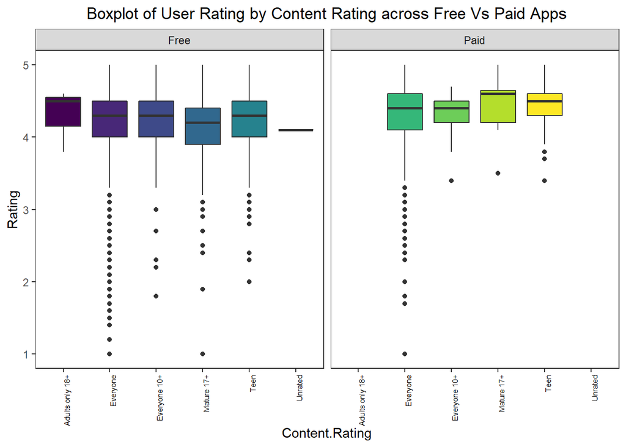

The box plots shows user ratings for the content rating “Everyone” have fairly same distribution for free and paid apps. However, there are non-existent apps in the “Adults only 18+” category for paid apps for which there are considerable amounts for free apps

### 5.4 SMART Question: How are free apps distributed by category

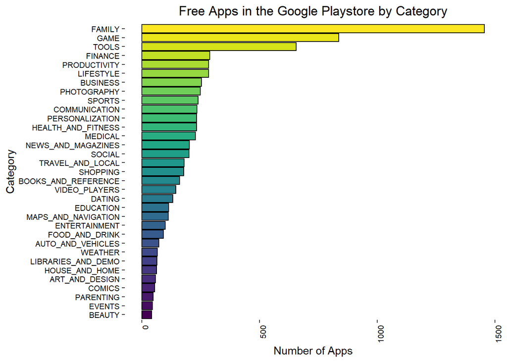

The bar plot above shows how free apps are distributed by app categories. We observed that the categories with highest number of free apps in Google PlayStore are Family, Game, Tools, Finance and Productivity

### 5.5 SMART Question: How are paid apps distributed by category

[figure not shown]

The bar plot above shows how paid apps are distributed by app categories. We observed that the categories with highest number of free apps in Google PlayStore are Family, Game, Personalization, Tools and Medical. Apparently, free and paid apps have similar representation across different categories

### 5.6 SMART Question:How are the apps distributed across different price categories

The price of apps is divided into categories, with the price range $0.99 - $9.99, $10 - $99.99 and $100 - $400 corresponding to cheap, expensive and very expensive respectively

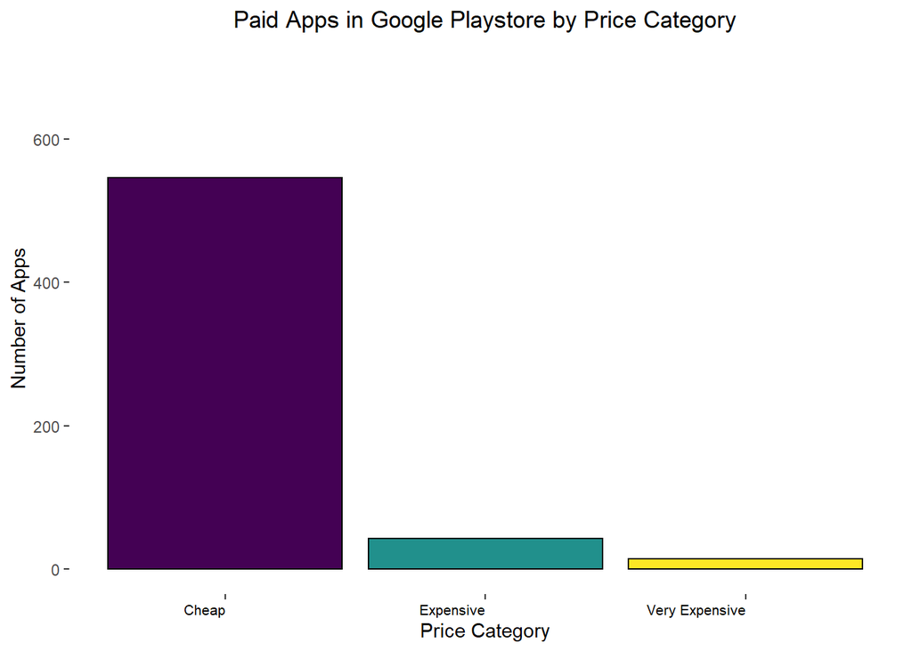

From the bar chart above, we observe that a majority of the paid apps fall under the cheap category with very few apps contained in the “Very Expensive” price category.

### 5.5 SMART Question: Are the average ratings the same across different price categories

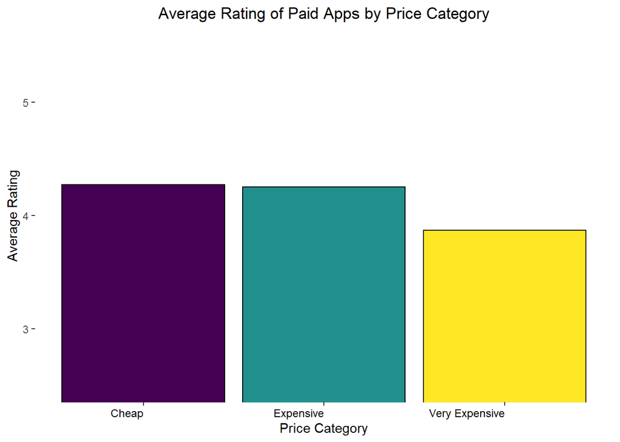

The average ratings for the different price categories appears to fall within a close range as observed from the plot above. To further understand how well the average ratings vary across the price categories, we carry out an ANOVA test on average ratings at the different price categories. We set up our null and alternate hypothesis as follows:

Null Hypothesis: The average ratings are the same across all price categories

Alternate Hypothesis: The average ratings are the different

The p-value of 0.0216944 is obtained which is lower than our alpha value of 0.05. Hence, we reject the null hypothesis and conclude that there is a significant difference in the average ratings across the different price categories.

To further understand the difference in average ratings between the price categories, we conducted a TukeyHSD test.The result shows a high p-value for the Expensive-Cheap pair, for which we fail to reject the null hypothesis and conclude there is no significant difference in the average ratings for the Expensive-Cheap categories.

The Box-plot below visualizes this in detail

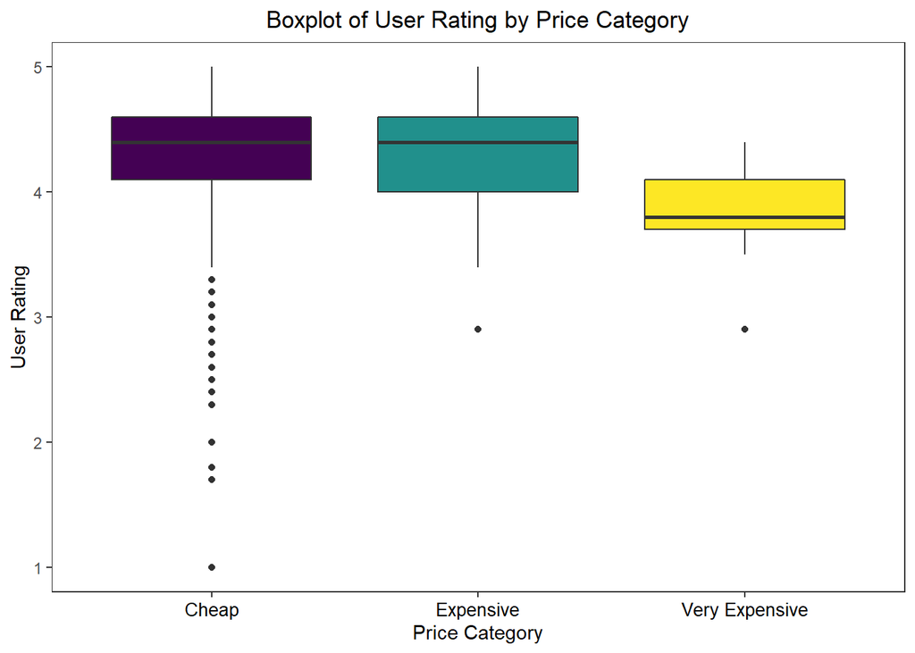

A plausible reason for the difference in the average ratings across the different price categories is that only a few apps are contained in the “Very Expensive” category when compared to other price categories.

## Section 6: Correlation and Linear Models

In this section, we seek to understand how different variables in Google PlayStore are related with each other

### 6.1 Plot correlation matrix

We plot a correlation matrix using only numerical variables from Google PlayStore.

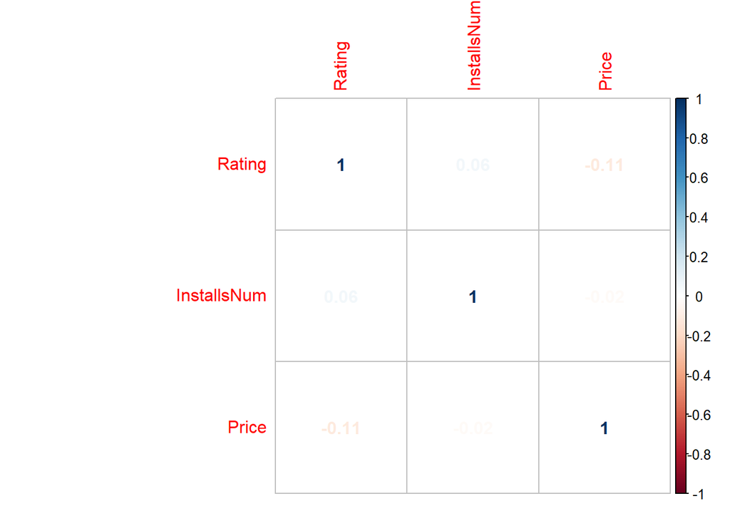

From the plot, the low correlation values shows us the variables are generally less correlated with one another. Rating is positively correlated with Number of Installs while negatively correlated with the Price of apps

### 6.2 Fit different linear models to rating variable

With rating as the target varible, we experiment with different variables to obtain a model that will produce a good fit

| Model | 1 (Price) | 2 (Installs) | 3 (Price+Installs) |  |
| --- | --- | --- | --- | --- |
| r<sup>2</sup> | 0.01268266 | 0.003588423 | 0.01596302 |  |
| Adj r<sup>2</sup> | 0.0110426 | 0.001933254 | 0.01268835 |  |
| Price | -0.00103979 (vif: 1) | ———- | -0.001027368 (vif: 1.000552) |  |
|  | p:0.00559 | ———– | p:0.00615 |  |
| Installs |  | NA (vif: 1 ) | NA (vif: 1.000552) |  |
|  |  | p:NA | p:NA |  |

## Section 7: Conclusion & Key Takeaways

### 7.1: Reflection on EDA

Throughout our EDA process, we have derived many useful insights from the Google Play Store dataset. To provide context of its current position in the market, we compared it with Apple’s App Store data and concluded that Google Play Store apps have higher ratings with a lower standard deviation than Apple’s apps. This phenomenon could be further explored but with the caveat that the users of each app source could have very different qualities and would thus be incomplete without analyzing user data as well.

Shifting attention to solely the Google Play Store data, our next section broke out ratings and price information by app category. It was interesting to see that the highest rated apps were in the Events category and that the lowest rated were in the Dating category. Finance and Lifestyle apps were by far the most expensive. When zeroing in on apps in the 95th rating percentile (4.8 or higher), the Family category came out on top.

We then analyzed differences in characteristics between price levels (cheap, expensive, and very expensive) across paid apps and concluded that there is a significant difference in the average ratings across price levels. Very expensive apps had a much lower rating than cheap and expensive apps, but the number of very expensive apps (as well as expensive apps) paled in comparison to the number of cheap apps.

Finally, we determined that this data would not produce a very reliable linear regression model as the r squared value is too low to draw any meaningful conclusions. We will explore this further in the next section.

### 7.2: Brainstorming for Future Data Utilization

When brainstorming possible future applications for our findings, we thought it would be useful to create a new variable related to popularity of an app. By combining user input variables into a score, we could apply this score to a prediction.

Reviewing the correlation of user input data (Rating, Installs, and Reviews), we found that the number of installs and reviews are highly correlated. This makes sense because the more installs an app has, the more opportunity it has to be rated by a user.

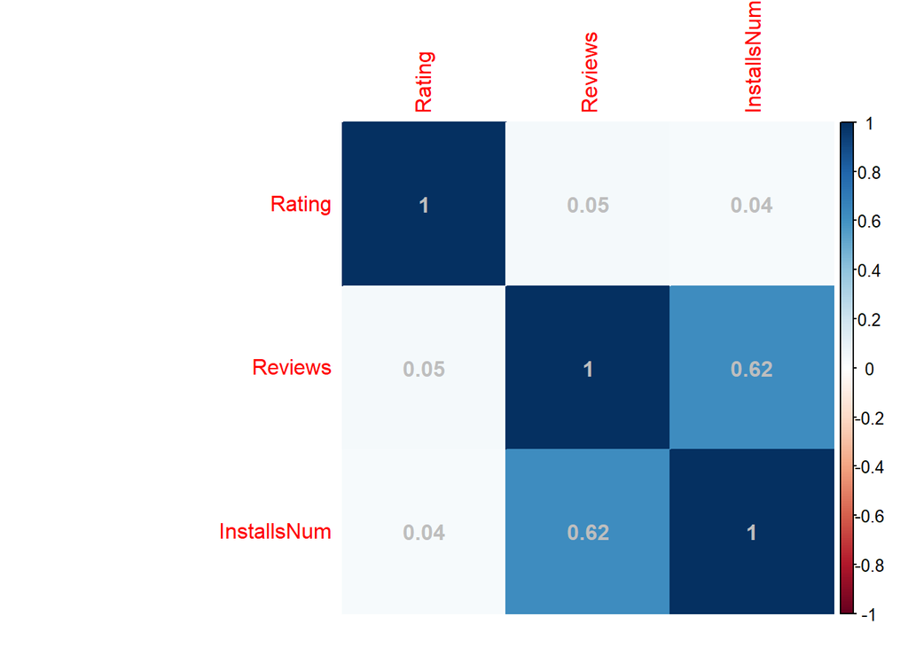

To test whether rating would be viable to contribute to the score, we checked to see if it is normally distributed. While left skewed, the distribution displays a curve with otherwise mostly normal qualities.

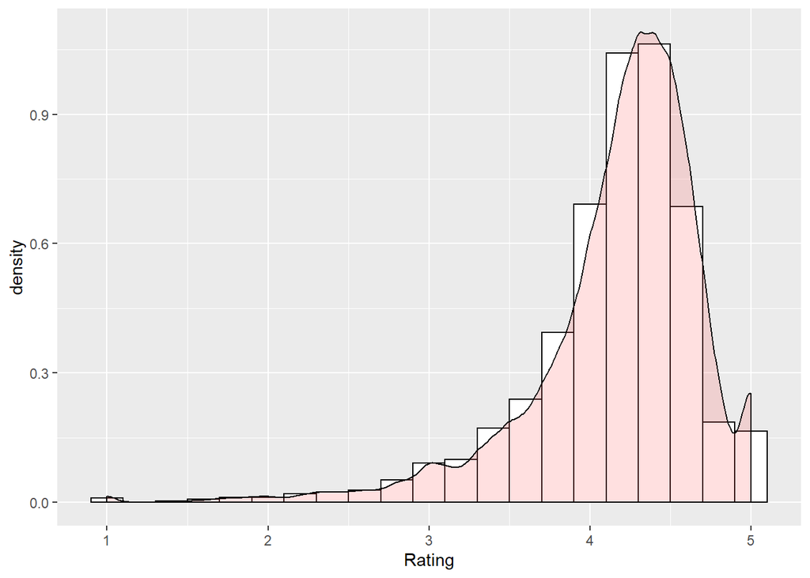

Looking at the Installs distribution presents a challenge. The scale is logarithmic with intervals at 10, 50, 100, 500, and so on. By bucketing the fives into their most previous ones, we can put the intervals in log10 buckets which are more straightforward to analyze. We can see that this distribution is fairly normal while slightly left skewed as well.

```
## # A tibble: 11 x 2
##    InstallsLog    count
##    <ord>          <int>
##  1 1+                12
##  2 10+              125
##  3 100+             502
##  4 1,000+          1122
##  5 10,000+         1444
##  6 100,000+        1598
##  7 1,000,000+      2022
##  8 10,000,000+      937
##  9 100,000,000+     212
## 10 1,000,000,000+    20
## 11 <NA>             202
```

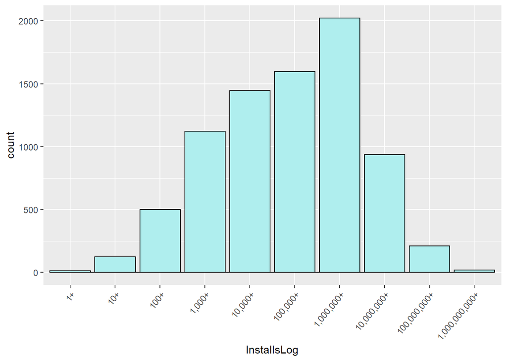

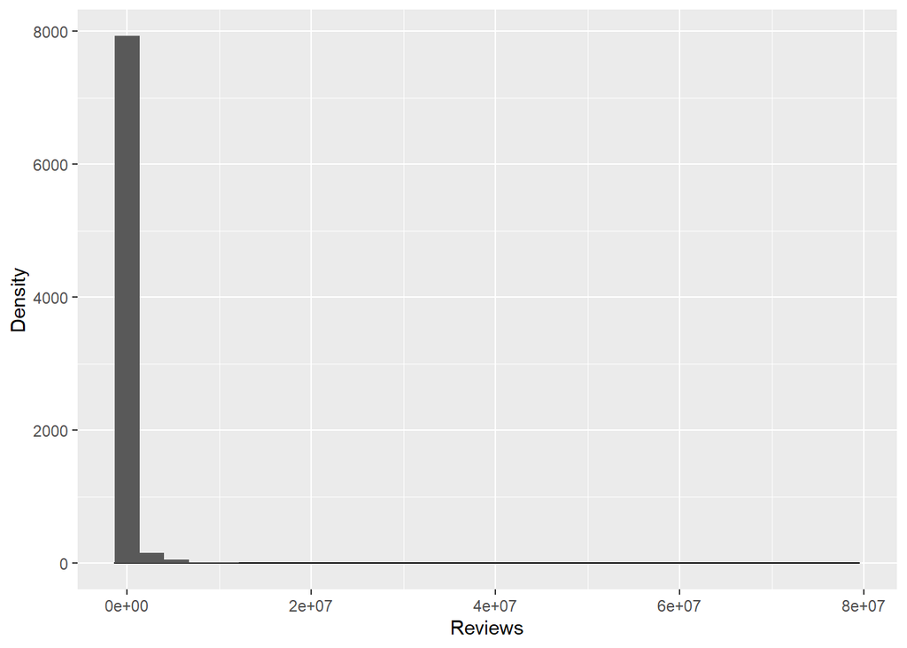

## References

Gartner. (August 1, 2019). Number of smartphones sold to end users worldwide from 2007 to 2020 (in million units) [Graph]. In Statista. Retrieved October 28, 2019, from https://www.statista.com/statistics/263437/global-smartphone-sales-to-end-users-since-2007/

Amarendra Bhushan Dhiraj (February 5, 2019). The Inexorable Rise: Apple’s iPhone Revenue From 2007 To 2019. Retrieved October 28, 2019, from https://ceoworld.biz/2019/02/05/the-inexorable-rise-apples-iphone-revenue-from-2007-to-2019/

AppBrain. (September 25, 2019). Number of available applications in the Google Play Store from December 2009 to September 2019 [Graph]. In Statista. Retrieved October 30, 2019, from https://www.statista.com/statistics/266210/number-of-available-applications-in-the-google-play-store/

PocketGamer.biz. (September 5, 2019). Number of available apps in the Apple App Store from 2008 to 2019 (in 1,000s) [Graph]. In Statista. Retrieved October 30, 2019, from https://www.statista.com/statistics/268251/number-of-apps-in-the-itunes-app-store-since-2008/